# Davidson & MacKinnon. Econometric Theory and Methods. (1999)

## Exercise 3.4.

### Plot the EDF (empirical distribution function) of the residuals from OLS estimation using one of the sets of simulated data, for the entire sample period, that you obtained in the last exercise; see Exercise 1.1 for a definition of the EDF. On the same graph, plot the CDF of the $N\left(0,\sigma^2\right)$ distribution, where $\sigma^2$ now denotes the variance you used to simulate the log of consumption. Show that the distributions characterized by the EDF and the normal CDF have the same mean but different variances. How could you modify the residuals so that the EDF of the modified residuals would have the same variance, $\sigma^2$, as the normal CDF?

We'll load "consumption.data.txt" provided by the authors in http://qed.econ.queensu.ca/ETM/data/.

```r
# Load consumption.data.txt
data = read.table("consumption.data.txt",col.names=c("n","year","quarter","income", "consumption"))
B = 200 #Defining number of simulations
```

We'll run the same regression as Exercise 3.3: $$\log (consumption) = \beta_1 + \beta_2 . \log (income) + u,$$ with all 200 observation, and get its residuals and standard deviation.

```r
#Running regression to get the estimates and sigma of the original data set
reg = lm(log(consumption) ~ log(income), data) ; summary(reg)
coeff = reg$coefficients
beta_1 = coeff["(Intercept)"]
beta_2 = coeff["log(income)"]
sigma = summary(reg)$sigma
```

```
Call:
lm(formula = log(consumption) ~ log(income), data = data)

Residuals:
      Min        1Q    Median        3Q       Max
-0.113024 -0.026878  0.008358  0.025481  0.090263

Coefficients:
            Estimate Std. Error t value Pr(>|t|)
(Intercept) 0.417736   0.048988   8.527 3.84e-15 ***
log(income) 0.956939   0.004046 236.543  < 2e-16 ***
---
Signif. codes:  0 '***' 0.001 '**' 0.01 '*' 0.05 '.' 0.1 ' ' 1

Residual standard error: 0.03581 on 198 degrees of freedom
Multiple R-squared:  0.9965,	Adjusted R-squared:  0.9965
F-statistic: 5.595e+04 on 1 and 198 DF,  p-value: < 2.2e-16
```

First, we will perform a parametric bootstrap to generate the first simulated data set of exercise 3.3, then we will perform the regression with all 200 observations and get its estimates.

```r
#First Simulation - Simulation by original observations order
#Parametric Bootstrap - considering the residuals have normal distribution with mean 0
set.seed(4321)
residual_boot = rnorm(B, 0, sd = sigma)
X = cbind(1, log(data$income))

log_consumption_sim1 = X %*% coeff + residual_boot

data_sim1 = data.frame("log_consumption_sim1" = log_consumption_sim1, "log_income" = log(data$income))

reg_ecf = lm(log_consumption_sim1 ~ log_income, data_sim1) #; summary(reg)
sigma_ecdf = summary(reg)$sigma
residuals_ecdf = summary(reg)$residuals
```

Plotting the empirical distribution, we observe that it clearly does not follow a normal distribution, butits mean is 0.

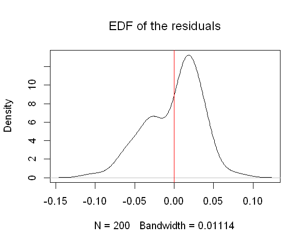

```r
#Plotting EDF
options(repr.plot.width=5, repr.plot.height=4)
plot(density(residuals_ecdf), main=expression("EDF of the residuals"))
abline(v=mean(residuals_ecdf), col="red")
```

Now, we'll sample a normal distribution with the standard deviation $\sigma=0.03581$ calculated by the previous regression. Then, we'll plot just show that it follow a normal distribution with mean 0.

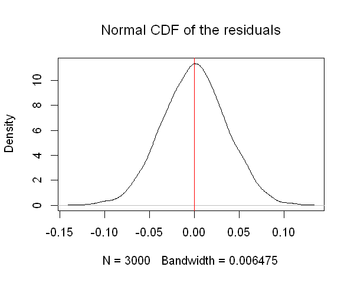

```r
#Generating a sample of residual considering N(0, sigma^2), used only for comparison in the next plot
set.seed(1234)
resid_norm = rnorm(3000, 0, sd = sigma)
plot(density(resid_norm), main=expression("Normal CDF of the residuals"))
abline(v=mean(resid_norm), col="red")
```

Analyzing the distributions of the residuals and of the normal sampled residuals, we observe again that the empirical distribution (in black) does not follow a normal distribution (in orange).

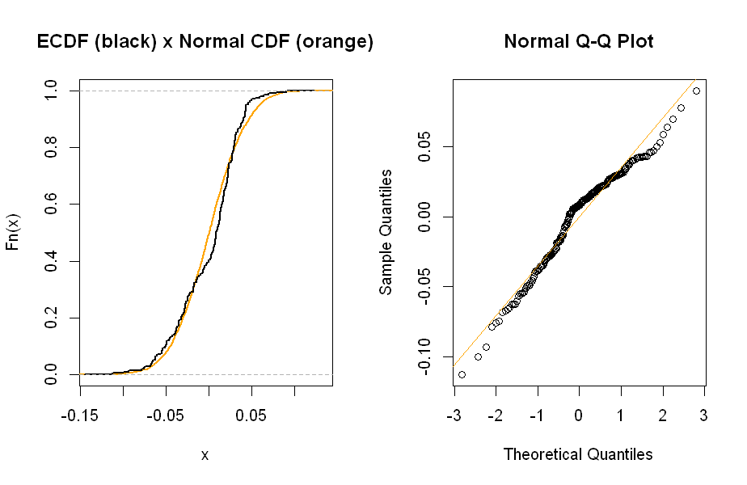

```r
#Plotting the cummulative density plot and qq-plot
options(repr.plot.width=7.7, repr.plot.height=5)
par(mfrow = c(1,2))
plot(ecdf(resid_norm), verticals=TRUE, do.points=FALSE, col="orange", lwd=2,
     main="ECDF (black) x Normal CDF (orange)")
plot(ecdf(residuals_ecdf), verticals=TRUE, do.points=FALSE, add=TRUE, lwd=2)

qqnorm(residuals_ecdf)
qqline(resid_norm, col="orange", lwd=1)
```

The mean of the distribution characterized by the normal CDF is evidently 0. This is also the mean of the distribution characterized by the EDF of the residuals, because the residuals sum to zero. $$$$ The variance of the distribution characterized by the normal CDF is $\sigma^2$. This is not the variance of the EDF of the residuals, which, by definition, is $$\sigma^2_{EDF}\, = \, \sum^n_{t=1} \hat{u}^2_t Pr(Z=\hat{u}_t) \, = \, \sum^n_{t=0} \frac{1}{n} \, = \, \frac{1}{n} \sum^n_{t=1} \hat{u}^2_t .$$ First, note that EDF variance is not equal to Normal CDF variance:

```r
#Comparing variance of distribution of normal CDF variance with variance of EDF
var_EDF = sum(residuals_ecdf^2)/200
sigma_EDF = sqrt(var_EDF)
print(paste("EDF variance =", round(var_EDF, 6), "<", round(sigma^2, 6), "Normal CDF variance"))
```

```
[1] "EDF variance = 0.001269 < 0.001282 Normal CDF variance"
```

If we adjust the residuals by multiplying them by $\sigma/\sigma_{EDF}$, we would have the a pretty close variance as the normal CDF.

```r
#Adjusting EDF variance and comparing with normal CDF variance again
adjusted_EDF_var = var(residuals_ecdf*sigma/sigma_EDF)
print(paste("Adjusted EDF variance =", round(adjusted_EDF_var, 6), "~", round(sigma^2, 6), "Normal CDF variance"))
```

```
[1] "Adjusted EDF variance = 0.001289 ~ 0.001282 Normal CDF variance"
```